# R Notebook - Unsupervised Learning ISLR Labs

### Principal Components

Using the USA Arrests dataset for unsupervised learning

`r`r dimnames(USArrests)

```
[[1]]
 [1] \Alabama\        \Alaska\         \Arizona\        \Arkansas\       \California\     \Colorado\       \Connecticut\
 [8] \Delaware\       \Florida\        \Georgia\        \Hawaii\         \Idaho\          \Illinois\       \Indiana\
[15] \Iowa\           \Kansas\         \Kentucky\       \Louisiana\      \Maine\          \Maryland\       \Massachusetts\
[22] \Michigan\       \Minnesota\      \Mississippi\    \Missouri\       \Montana\        \Nebraska\       \Nevada\
[29] \New Hampshire\  \New Jersey\     \New Mexico\     \New York\       \North Carolina\ \North Dakota\   \Ohio\
[36] \Oklahoma\       \Oregon\         \Pennsylvania\   \Rhode Island\   \South Carolina\ \South Dakota\   \Tennessee\
[43] \Texas\          \Utah\           \Vermont\        \Virginia\       \Washington\     \West Virginia\  \Wisconsin\
[50] \Wyoming\

[[2]]
[1] \Murder\   \Assault\  \UrbanPop\ \Rape\
```

`r`r apply(USArrests,2,mean)

```
  Murder  Assault UrbanPop     Rape
   7.788  170.760   65.540   21.232
```

`r`r apply(USArrests,2, var)

```
    Murder    Assault   UrbanPop       Rape
  18.97047 6945.16571  209.51878   87.72916
```

Principal Components is about the Variance (Mean will be made 0). We see that Assault has the most variance. If a single variable has a lot of variance, it might dominate the principal components

We calculate the PCA by standardizing the variables

`r`r #prcomp will standardize the variables for us pca.out=prcomp(USArrests, scale=TRUE) pca.out

```
Standard deviations (1, .., p=4):
[1] 1.5748783 0.9948694 0.5971291 0.4164494

Rotation (n x k) = (4 x 4):
                PC1        PC2        PC3         PC4
Murder   -0.5358995  0.4181809 -0.3412327  0.64922780
Assault  -0.5831836  0.1879856 -0.2681484 -0.74340748
UrbanPop -0.2781909 -0.8728062 -0.3780158  0.13387773
Rape     -0.5434321 -0.1673186  0.8177779  0.08902432
```

The standard deviations are the SD of the four principal components. The rotation are the loadings - The 1 PC is loaded equally on Murder, Assault, Rape (all the three crimes) and loaded less on the Urban population. The sign doesnt matter really, because the variance doesnt change - The second is heavily loaded on the urban population

Plotting the first two components

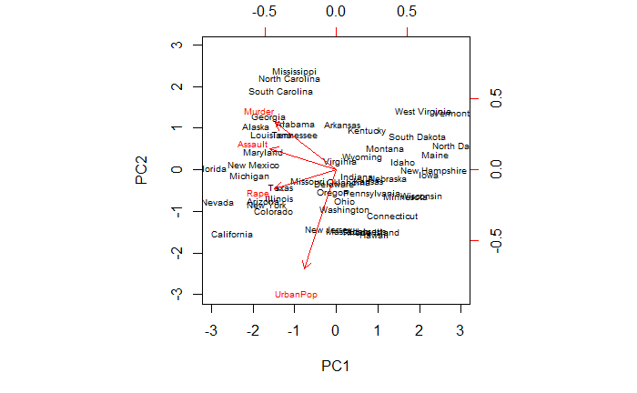

The red is the direction of the loadings of the principal components while each state takes a position on the x plot.

Eg. Florida, Nevada, California is high on crime. Maine, North Dakota, New Hampshire have low crime The y axis is about whether the state has a high population or not

### K - Means Clustering

We work on a simulated data, where we have clusters and we shift them by shifting their means

`r`r set.seed(101) #Generating 2 columns, 100 records x <- matrix(rnorm(100*2), 100, 2) #Generating means and shiting means for the 4 clusters xmean <- matrix(rnorm(8, sd = 4), 4, 2) #Which point is going to be placed on which cluster? which <- sample(1:4, 100, replace = TRUE) #xmean[which,] produces a 100 row matrix with 2 columns x <- x + xmean[which,] plot(x, col = which, pch = 19)

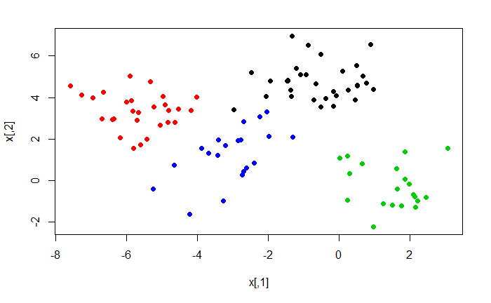

Running a kmeans on this dataset

`r`r #We run 15 random starts (15 times algorithm, each time the starting cluster assignment is different) kmout <- kmeans(x, 4, nstart = 15) kmout

```
K-means clustering with 4 clusters of sizes 32, 28, 20, 20

Cluster means:
        [,1]       [,2]
1 -0.5787702  4.7639233
2 -5.6518323  3.3513316
3  1.4989983 -0.2412154
4 -3.1104142  1.2535711

Clustering vector:
  [1] 2 4 1 2 4 1 2 4 1 1 3 1 1 3 4 3 2 3 2 2 2 2 2 3 1 1 4 2 4 1 2 3 2 4 4 3 3 4 3 3 2 4 4 2 2 3 2 1 2 4 2 1 1 3 3 4 3 1 1 1 4 2 2
 [64] 2 4 4 1 1 3 2 2 1 1 3 1 3 2 1 1 1 4 1 4 1 2 3 1 2 2 1 1 4 2 4 1 1 3 3 1 1

Within cluster sum of squares by cluster:
[1] 53.04203 42.40322 34.95921 48.52107
 (between_SS / total_SS =  85.7 %)

Available components:

[1] \cluster\      \centers\      \totss\        \withinss\     \tot.withinss\ \betweenss\    \size\         \iter\
[9] \ifault\
```

- Cluster Means - Centroid
- Cluster Vector - Assignment of cluster to the data point
- Within cluster sum of squares is summary of the cluster
- between sum of squares/total sum of squares is like R^2 for clustering. It is the percentage of variance explained by the clustering

Plotting the data

`r`r #Clusters plot(x, col = kmout$cluster, cex = 2, pch = 1, lwd = 2) #Plotting the original data points(x, col = which, pch = 19)

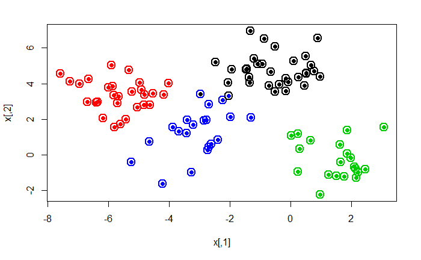

There are one or two mismatches between the blue and black. They are much closer to each other and this result is reasonable.

### Hierarchical Clustering

We use the same simulated dataset for hierarchical clustering

Computing the clusters based on different link functions and plotting the dendogram (bottom-up clustering)

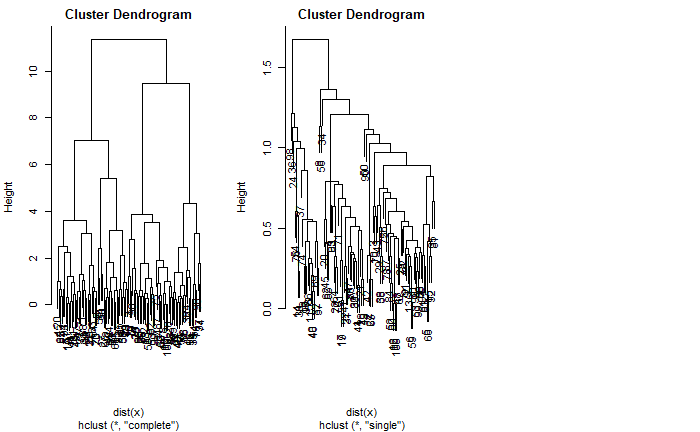

Complete is the prefered method

“cuttree” is a function used to get the clusters at a preferred height level. We compare this with the original data

`r`r table(hc_cut, which)

```
      which
hc_cut  1  2  3  4
     1  0 28  0  0
     2  1  0  0 20
     3 31  0  0  0
     4  0  0 20  0
```

The orders are actually arbitrary. THe small numers are the misidentifications. 1 in hc_cut is not the same as 1 in original data

Comparing with K-Means clustering (4 clusters)

`r`r table(hc_cut, kmout$cluster)

```
hc_cut  1  2  3  4
     1  0 28  0  0
     2  1  0  0 20
     3 31  0  0  0
     4  0  0 20  0
```

We see similar results for the kmeans and hierarchical clustering

The dendograms can be labelled with the original cluster assignments in order to see misassignments

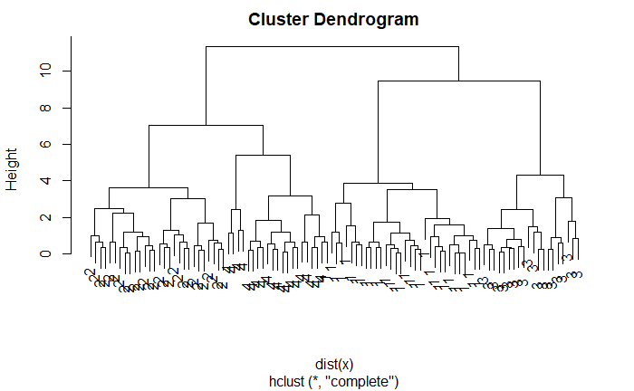